# nlminb in R 4.5.2 and R 4.6.2: opal jitter benchmark

Published

November 20, 2026

## Question

R 4.6.2’s NEWS lists one change to `nlminb()`:

> Fix long standing (Fortran compiler optimization related) bug in nlminb with constraints, thanks to Kasper Kristensen’s PR#19086 report and patch.

The entry does not mention speed. This note checks whether opal fits with bounds run faster, take a different path, or reach different optima under R 4.6.2 than under R 4.5.2, the version in opal’s `renv.lock`, and whether any difference comes from the fix or from the compiler used to build R.

## Setup

|  | R 4.5.2 | R 4.6.2 |
| --- | --- | --- |
| R | R version 4.5.2 (2025-10-31) | R version 4.6.2 (2026-10-29) |
| opal | 0.1.3 | 0.1.3 |
| RTMB | 2.0 | 2.0 |
| TMB | 1.9.23 | 1.9.23 |
| Matrix | 1.7.6 | 1.7.6 |
| RcppEigen | 0.3.4.0.2 | 0.3.4.0.2 |
| BLAS | libopenblasp-r0.3.34.so | libopenblasp-r0.3.34.so |
| LAPACK | libopenblasp-r0.3.34.so | libopenblasp-r0.3.34.so |
| stats.so built with | GCC: (conda-forge gcc 10.4.0-19) 10.4.0 | GCC: (conda-forge gcc 15.3.0-7) 15.3.0 |
| CPU | Intel(R) Xeon(R) Processor @ 2.10GHz | Intel(R) Xeon(R) Processor @ 2.10GHz |

- Both R versions are conda-forge builds, run on one cloud container (Intel(R) Xeon(R) Processor @ 2.10GHz, 4 cores). conda-forge has no R packages built for 4.6 yet, so every package in the 4.6.2 library was built from source at the version in the 4.5.2 library (`setup-r462.sh`); RTMB, RTMBdist, StanEstimators, SparseNUTS and opal (`dev` at `87c5494`) were built from the same source in both.
- Models: the Opakapaka quickstart fit (127 parameters) and the IO yellowfin article model AGE-SF (319 parameters), rebuilt from the fits stored in opal’s `inst/extdata` with the stored bounds and `nlminb` control (`eval.max = iter.max = 10000`). All parameters have finite bounds.
- Fits: two `nlminb` passes with bounds, as in `opal_fit()`. Start 0 is the stored model’s initial values; starts 1 to N are jittered from the stored estimate. Calls to `fn` and `gr` are counted with the wrapper from opal’s `helper-benchmark.R`.
- Jitter: the SS3 3.30 scheme with a jitter fraction of 0.1 on every parameter. Draws whose objective or gradient was not finite (nlminb stops at once on those) were redrawn: 18 for Opakapaka and 7 for IO yellowfin. Both R versions used the same starts.
- Timing: each fit runs in a fresh R process, one at a time, single-threaded BLAS. The order of the two R versions alternates from start to start. Each fit is repeated in its process (5 times for Opakapaka, 3 for IO yellowfin) and the median time of the `nlminb` calls is reported.

## Controls

Before attributing any difference to `nlminb`, the model’s arithmetic must be the same under both versions.

| Check | Compared | Identical (fraction) |
| --- | --- | --- |
| Stored trajectory replay, opaka | 100 calls | 1 |
| Stored trajectory replay, io_yft | 100 calls | 1 |
| Objective and gradient at the jittered starts, IO yellowfin (AGE-SF) | 11 starts (fn and gr) | 1 |
| Objective and gradient at the jittered starts, Opakapaka | 21 starts (fn and gr) | 1 |

The trajectory replay uses opal’s stored benchmark trajectories (`tests/testthat/_benchmark/trajectories`; Opakapaka quickstart and the bundled IO yellowfin LEN inputs), sampled to at most 100 `fn` and 100 `gr` calls each.

Time per objective and gradient call at the estimate (median of 5 blocks).

| Model | fn, R 4.5.2 (ms) | fn, R 4.6.2 (ms) | gr, R 4.5.2 (ms) | gr, R 4.6.2 (ms) |
| --- | --- | --- | --- | --- |
| Opakapaka | 0.635 | 0.715 | 1.205 | 1.135 |
| IO yellowfin (AGE-SF) | 12.150 | 10.950 | 25.050 | 24.800 |

nlminb on a 200-parameter extended Rosenbrock function in plain R (no opal); bounded: all parameters in [-1.5, 0.8]. Time is the mean of 20 runs.

| problem | r_version | seconds | iterations | fn_evals | gr_evals | objective |
| --- | --- | --- | --- | --- | --- | --- |
| unbounded | R 4.5.2 | 0.1231 | 730 | 1129 | 731 | 0 |
| bounded | R 4.5.2 | 0.0296 | 165 | 191 | 165 | 4 |
| unbounded | R 4.6.2 | 0.1373 | 730 | 1129 | 731 | 0 |
| bounded | R 4.6.2 | 0.0372 | 209 | 271 | 209 | 4 |

## Results

Jittered starts (start 0 excluded).

| Model | Starts | Median time 4.5.2 (s) | Median time 4.6.2 (s) | Median ratio 4.6.2/4.5.2 | Same fn/gr counts | Median gr calls 4.5.2 | Median gr calls 4.6.2 | Same end point (\|objective difference\| < 1e-4) | Total time 4.5.2 (s) | Total time 4.6.2 (s) |
| --- | --- | --- | --- | --- | --- | --- | --- | --- | --- | --- |
| IO yellowfin (AGE-SF) | 10 | 14.22 | 9.39 | 0.67 | 0 | 542.5 | 330.5 | 3 | 569.19 | 124.69 |
| Opakapaka | 20 | 0.71 | 0.22 | 0.28 | 0 | 497.5 | 138.0 | 17 | 16.15 | 4.37 |

Jittered starts where both versions reached the same end point, so the work compared is for the same result.

| Model | Starts | Median time 4.5.2 (s) | Median time 4.6.2 (s) | Median gr calls 4.5.2 | Median gr calls 4.6.2 |
| --- | --- | --- | --- | --- | --- |
| IO yellowfin (AGE-SF) | 3 | 11.05 | 8.50 | 436 | 287 |
| Opakapaka | 17 | 0.65 | 0.21 | 451 | 134 |

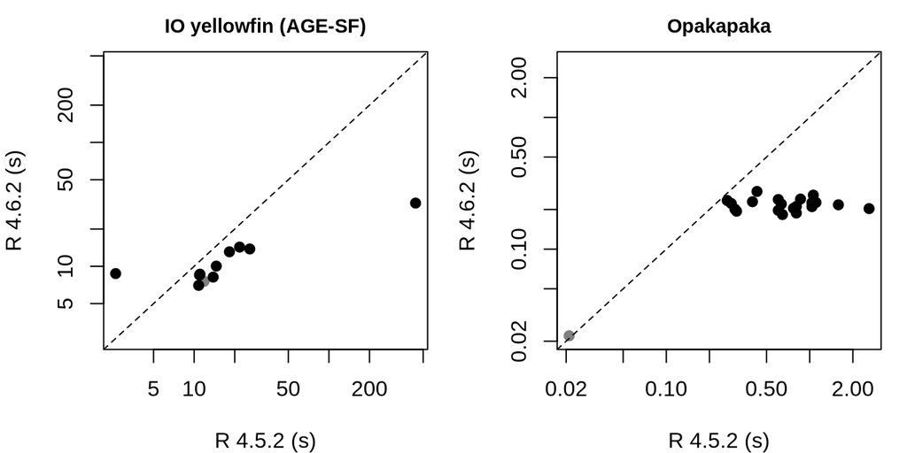

Figure 1: Time per fit (median of repeats) for each start, R 4.6.2 against R 4.5.2, log scales. The line is equal time; grey is start 0.

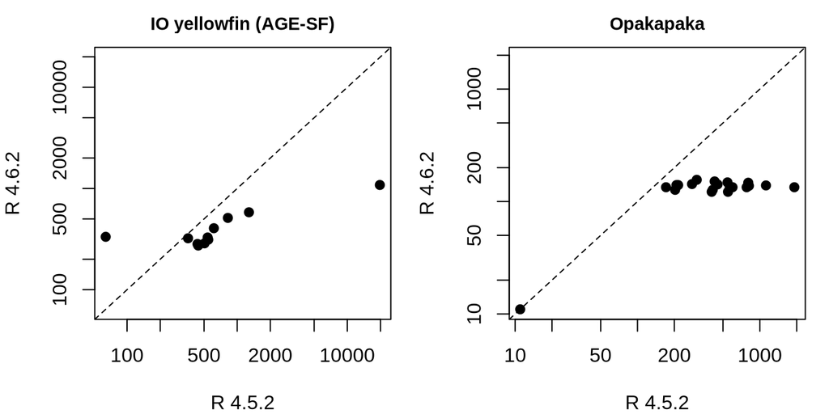

Figure 2: Gradient calls per fit, R 4.6.2 against R 4.5.2, log scales.

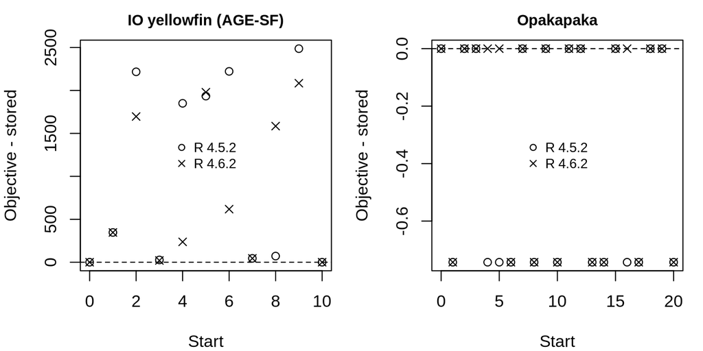

Figure 3: Final objective minus the stored estimate’s objective, per start. Values below 0 are lower than the stored fit.

Every fit. Time in seconds; dObj is the final objective minus the stored estimate’s objective; the last column compares the two versions’ final parameters.

| Model | Start | Time 4.5.2 | Time 4.6.2 | gr 4.5.2 | gr 4.6.2 | Conv 4.5.2 | Conv 4.6.2 | dObj 4.5.2 | dObj 4.6.2 | Max \|par diff\| |
| --- | --- | --- | --- | --- | --- | --- | --- | --- | --- | --- |
| IO yellowfin (AGE-SF) | 0 | 11.86 | 7.57 | 443 | 273 | 0 | 0 | 0.000 | 0.000 | 0.000087 |
| IO yellowfin (AGE-SF) | 1 | 10.96 | 8.50 | 436 | 283 | 0 | 0 | 346.545 | 346.545 | 0.001469 |
| IO yellowfin (AGE-SF) | 2 | 2.62 | 8.74 | 64 | 333 | 1 | 0 | 2217.456 | 1696.746 | 5.307654 |
| IO yellowfin (AGE-SF) | 3 | 10.81 | 7.01 | 546 | 312 | 0 | 0 | 26.719 | 20.526 | 4.411227 |
| IO yellowfin (AGE-SF) | 4 | 25.87 | 13.81 | 1279 | 582 | 0 | 0 | 1850.437 | 237.038 | 3.854670 |
| IO yellowfin (AGE-SF) | 5 | 439.43 | 32.38 | 19741 | 1083 | 1 | 1 | 1934.160 | 1979.863 | 5.612201 |
| IO yellowfin (AGE-SF) | 6 | 21.74 | 14.29 | 823 | 512 | 0 | 0 | 2222.509 | 617.985 | 3.655329 |
| IO yellowfin (AGE-SF) | 7 | 11.05 | 8.64 | 358 | 322 | 0 | 0 | 44.929 | 44.929 | 0.000234 |
| IO yellowfin (AGE-SF) | 8 | 18.28 | 13.10 | 614 | 405 | 0 | 0 | 71.644 | 1585.020 | 2.954186 |
| IO yellowfin (AGE-SF) | 9 | 14.60 | 10.04 | 539 | 328 | 0 | 0 | 2486.983 | 2084.648 | 5.456349 |
| IO yellowfin (AGE-SF) | 10 | 13.84 | 8.18 | 505 | 287 | 0 | 0 | 0.000 | 0.000 | 0.000822 |
| Opakapaka | 0 | 0.02 | 0.02 | 11 | 11 | 0 | 0 | 0.000 | 0.000 | 0.000000 |
| Opakapaka | 1 | 0.77 | 0.20 | 549 | 122 | 0 | 0 | -0.743 | -0.743 | 0.000016 |
| Opakapaka | 2 | 0.60 | 0.24 | 427 | 151 | 0 | 0 | 0.000 | 0.000 | 0.000033 |
| Opakapaka | 3 | 0.65 | 0.18 | 404 | 122 | 0 | 0 | 0.000 | 0.000 | 0.000013 |
| Opakapaka | 4 | 1.11 | 0.23 | 800 | 138 | 0 | 0 | -0.743 | 0.000 | 0.580665 |
| Opakapaka | 5 | 1.04 | 0.22 | 804 | 147 | 0 | 0 | -0.743 | 0.000 | 0.580656 |
| Opakapaka | 6 | 0.27 | 0.23 | 171 | 134 | 0 | 0 | -0.743 | -0.743 | 0.000012 |
| Opakapaka | 7 | 0.28 | 0.22 | 215 | 140 | 0 | 0 | 0.000 | 0.000 | 0.000020 |
| Opakapaka | 8 | 0.31 | 0.19 | 203 | 127 | 0 | 0 | -0.743 | -0.743 | 0.000014 |
| Opakapaka | 9 | 1.04 | 0.21 | 814 | 138 | 0 | 0 | 0.000 | 0.000 | 0.000015 |
| Opakapaka | 10 | 1.59 | 0.22 | 1122 | 139 | 0 | 0 | -0.743 | -0.743 | 0.000025 |
| Opakapaka | 11 | 0.60 | 0.20 | 412 | 127 | 0 | 0 | 0.000 | 0.000 | 0.000014 |
| Opakapaka | 12 | 0.30 | 0.20 | 208 | 140 | 0 | 0 | 0.000 | 0.000 | 0.000013 |
| Opakapaka | 13 | 1.06 | 0.26 | 780 | 134 | 0 | 0 | -0.743 | -0.743 | 0.000009 |
| Opakapaka | 14 | 0.86 | 0.24 | 544 | 148 | 0 | 0 | -0.743 | -0.743 | 0.000017 |
| Opakapaka | 15 | 0.81 | 0.19 | 598 | 134 | 0 | 0 | 0.000 | 0.000 | 0.000016 |
| Opakapaka | 16 | 0.43 | 0.27 | 305 | 156 | 0 | 0 | -0.743 | 0.000 | 0.580675 |
| Opakapaka | 17 | 2.60 | 0.20 | 1914 | 134 | 0 | 0 | -0.743 | -0.743 | 0.000024 |
| Opakapaka | 18 | 0.63 | 0.22 | 451 | 142 | 0 | 0 | 0.000 | 0.000 | 0.000014 |
| Opakapaka | 19 | 0.40 | 0.23 | 279 | 143 | 0 | 0 | 0.000 | 0.000 | 0.000011 |
| Opakapaka | 20 | 0.81 | 0.21 | 568 | 133 | 0 | 0 | -0.743 | -0.743 | 0.000008 |

## Same-compiler test

The two R builds differ in both the PORT code and the compiler. To separate the two, R’s PORT source (`src/library/stats/src/port.c` and `portsrc.f`) was taken from the R 4.5.2 and R 4.6.2 tags of the R source mirror on GitHub and compiled into five standalone libraries (`same-compiler/build-port-variants.sh`). The only change to `portsrc.f` between the two tags is the fix:

```fortran
-         CALL DL7TVM(N, V(X01), V(L), V(X01))
-         CALL DL7VML(N, V(X01), V(L), V(X01))
+         TEMP1 = IV(STLSTG)
+         CALL DL7TVM(N, V(TEMP1), V(L), V(X01))
+         CALL DL7VML(N, V(X01), V(L), V(TEMP1))
```

In the old code the same array is passed as both input and output of `DL7TVM` and `DL7VML`. Fortran does not allow this, so an optimising compiler may produce code whose result differs from the one the authors intended. The fix passes a separate work vector.

`portsrc.f` was compiled with the same flags as R’s builds (`SAFE_FFLAGS`), by the same conda-forge compilers that built each R version’s `stats` library; `port.c` (C glue, no change of substance between the tags) was compiled with GCC 15.3 in every variant. Each library was loaded into R 4.6.2 behind a copy of R 4.6.2’s `nlminb()`, so R, BLAS, the model and the starts are the same for every variant.

Fits (start 0 and the jittered starts) whose objective and gradient call counts and final objective are identical to those of stats::nlminb in R 4.5.2 or R 4.6.2 (main benchmark).

| Model | Variant | Fits | Identical to R 4.5.2 | Identical to R 4.6.2 |
| --- | --- | --- | --- | --- |
| IO yellowfin (AGE-SF) | A: old code, GCC 10.4, -O2 | 11 | 11 | 0 |
| IO yellowfin (AGE-SF) | B: old code, GCC 15.3, -O2 | 11 | 11 | 0 |
| IO yellowfin (AGE-SF) | C: fixed code, GCC 10.4, -O2 | 11 | 0 | 11 |
| IO yellowfin (AGE-SF) | D: fixed code, GCC 15.3, -O2 | 11 | 0 | 11 |
| IO yellowfin (AGE-SF) | E: old code, GCC 10.4, -O0 | 11 | 0 | 11 |
| Opakapaka | A: old code, GCC 10.4, -O2 | 21 | 21 | 0 |
| Opakapaka | B: old code, GCC 15.3, -O2 | 21 | 21 | 0 |
| Opakapaka | C: fixed code, GCC 10.4, -O2 | 21 | 0 | 21 |
| Opakapaka | D: fixed code, GCC 15.3, -O2 | 21 | 0 | 21 |
| Opakapaka | E: old code, GCC 10.4, -O0 | 21 | 0 | 21 |

Bounded Rosenbrock problem (plain R) with each variant. Without bounds all variants take the same path (730 iterations).

| Variant | Iterations | fn calls | gr calls | Objective |
| --- | --- | --- | --- | --- |
| stats::nlminb (R 4.6.2) | 209 | 271 | 209 | 4 |
| A: old code, GCC 10.4, -O2 | 165 | 191 | 165 | 4 |
| B: old code, GCC 15.3, -O2 | 165 | 191 | 165 | 4 |
| C: fixed code, GCC 10.4, -O2 | 209 | 271 | 209 | 4 |
| D: fixed code, GCC 15.3, -O2 | 209 | 271 | 209 | 4 |
| E: old code, GCC 10.4, -O0 | 209 | 271 | 209 | 4 |

Jittered starts by variant, all run in R 4.6.2 (times: median of 3 repeats for Opakapaka, 1 run for IO yellowfin).

| Model | Variant | Median gr calls | Median time (s) | Total time (s) |
| --- | --- | --- | --- | --- |
| IO yellowfin (AGE-SF) | A: old code, GCC 10.4, -O2 | 542.5 | 14.58 | 660.45 |
| IO yellowfin (AGE-SF) | B: old code, GCC 15.3, -O2 | 542.5 | 14.23 | 620.25 |
| IO yellowfin (AGE-SF) | C: fixed code, GCC 10.4, -O2 | 330.5 | 10.06 | 134.83 |
| IO yellowfin (AGE-SF) | D: fixed code, GCC 15.3, -O2 | 330.5 | 10.36 | 136.96 |
| IO yellowfin (AGE-SF) | E: old code, GCC 10.4, -O0 | 330.5 | 10.34 | 147.31 |
| Opakapaka | A: old code, GCC 10.4, -O2 | 497.5 | 0.64 | 15.69 |
| Opakapaka | B: old code, GCC 15.3, -O2 | 497.5 | 0.73 | 16.51 |
| Opakapaka | C: fixed code, GCC 10.4, -O2 | 138.0 | 0.21 | 4.29 |
| Opakapaka | D: fixed code, GCC 15.3, -O2 | 138.0 | 0.22 | 4.51 |
| Opakapaka | E: old code, GCC 10.4, -O0 | 138.0 | 0.24 | 4.87 |

Results:

- **The compiler version had no effect** between GCC 10.4 and 15.3. A and B (old code) give identical results to each other and to R 4.5.2 at every fit; C and D (fixed code) give identical results to each other and to R 4.6.2.
- **The code change accounts for every difference** between R 4.5.2 and R 4.6.2 in this benchmark, including the evaluation counts, the end points and the plain-R problem.
- **Optimisation is what triggers the bug.** The old code compiled without optimisation (E, `-O0`) gives results identical to the fixed code at every fit. Compiled at `-O2` by either compiler, the old code computes a different result. The agreement of E with the fixed code indicates that the fixed code computes what the old code was written to compute, and that the optimised builds of the old code (R 4.5.2 here) did not.

## Interpretation

**Model arithmetic.** Both builds return identical objective and gradient values in the trajectory replay and at every start. The cost per call differs by 13% or less between versions, and not consistently in one direction. The differences below therefore come from the path `nlminb` takes, not from the model.

**Opakapaka.** R 4.6.2 used fewer gradient calls at all 20 jittered starts (median 138 against 497.5) and took a median 0.28 of R 4.5.2’s time. The fits ended at one of two minima, 1831.669 and 1832.412; the stored quickstart estimate is the higher one. R 4.5.2 reached the lower minimum from 11 starts and R 4.6.2 from 8; the 3 starts where the versions disagree all ended lower under R 4.5.2. Fewer evaluations did not mean a better end point here.

**IO yellowfin.** R 4.6.2 used fewer gradient calls at 9 of 10 starts; the median time ratio was 0.67 (range 0.07 to 3.34). The total time is dominated by start 5, where R 4.5.2 reached the evaluation limit (19741 gradient calls) and R 4.6.2 stopped after 1083 with false convergence. Only 1 jittered start returned to the stored estimate under either version; with a jitter fraction of 0.1 this 319-parameter model mostly ends in worse local minima. The two versions ended at different points from 7 starts (R 4.6.2 lower at 5, higher at 2), so for this model most time comparisons are between fits that did not reach the same result. At the 3 starts where they did, R 4.6.2 was faster (table above).

**Plain-R problem.** Without bounds, both versions took the same path (730 iterations). With bounds, R 4.6.2 needed more iterations (209 against 165) and more time, for the same solution. In this example only the bounded run changed, in line with the NEWS entry, and R 4.6.2 did more work, not less.

**Inference.** The same-compiler test shows that the differences between R 4.5.2 and R 4.6.2 come from the `nlminb` fix, not from the compiler. Whenever the old `portsrc.f` was compiled with optimisation (`-O2`, either GCC), it took a different path from the unoptimised old code and the fixed code. For these two opal models, the intended path (R 4.6.2) needed fewer evaluations and less time at most jittered starts; for the plain-R problem it needed more. Neither version reached better end points consistently. The samples are small, so the size of the speed-up for other models cannot be inferred from these results.

## Limitations

- conda-forge built R 4.5.2’s `stats` library (which holds `nlminb`’s PORT code) with GCC: (conda-forge gcc 10.4.0-19) 10.4.0 and R 4.6.2’s with GCC: (conda-forge gcc 15.3.0-7) 15.3.0. The same-compiler test separates the code change from this compiler change for these two GCC versions at `-O0` and `-O2` only. Other compilers and flags (e.g. the gfortran builds used for CRAN’s Windows and macOS R, or `-O3`) were not tested, so whether a given R < 4.6.2 installation shows the old behaviour has to be checked on that installation. One machine was used.
- In the same-compiler test, `port.c` was compiled with GCC 15.3 in every variant (R 4.6’s headers need C23 support that GCC 10 lacks). Variants A and B still reproduce R 4.5.2’s results exactly, so this did not affect them.
- Small samples: 20 and 10 jittered starts. The jitter draws were limited to starts with a finite objective and gradient.
- Timings come from a shared cloud container. Alternating the order of the versions and repeating each fit reduce, but do not remove, drift and noise.
- Packages in the 4.5.2 library are conda-forge binaries; in the 4.6.2 library they were compiled here from the same versions. The controls above check that the model’s arithmetic agrees; they cannot rule out differences in code paths that the controls do not exercise.
- Two packages differ from the 4.5.2 library: checkmate is 2.3.4 in R 4.6.2 (2.3.3 does not compile against R 4.6) and bibtex is added (needed to build mvtnorm). Neither is used in the model calculations.
- Only `nlminb()` with opal’s default control settings was tested.

## Reproduce

```bash
OPAL_SOURCE=/path/to/opal bash benchmarks/nlminb-r46/setup-r452.sh
bash benchmarks/nlminb-r46/setup-r462.sh /opt/r452 $HOME/r-setup-r452/src
OPAL_SOURCE=/path/to/opal bash benchmarks/nlminb-r46/run-benchmark.sh
bash benchmarks/nlminb-r46/same-compiler/run-same-compiler.sh
quarto render benchmarks/nlminb-r46/nlminb-r46.qmd
```